# Introduction

[figure not shown]

This dataset was scraped from [nextspaceflight.com](https://nextspaceflight.com/launches/past/?page=1) and includes all the space missions since the beginning of Space Race between the USA and the Soviet Union in 1957!

### Install Package with Country Codes

```python
%pip install iso3166
```

### Upgrade Plotly

Run the cell below if you are working with Google Colab.

```python
%pip install --upgrade plotly
```

```python
pip install matplotlib
```

```python
pip install seaborn
```

### Import Statements

```python
import numpy as np
import pandas as pd
import plotly.express as px
import matplotlib.pyplot as plt
import seaborn as sns

# These might be helpful:
from iso3166 import countries
from datetime import datetime, timedelta
```

### Notebook Presentation

```python
pd.options.display.float_format = '{:,.2f}'.format
```

### Load the Data

```python
df_data = pd.read_csv('mission_launches.csv')
```

# Preliminary Data Exploration

- What is the shape of `df_data`?
- How many rows and columns does it have?
- What are the column names?
- Are there any NaN values or duplicates?

```python
df_data.shape
```

```
(4324, 9)
```

```python
df_data.columns
```

```
Index(['Unnamed: 0', 'Unnamed: 0.1', 'Organisation', 'Location', 'Date',
       'Detail', 'Rocket_Status', 'Price', 'Mission_Status'],
      dtype='object')
```

```python
df_data.isnull().sum()
```

```
Unnamed: 0           0
Unnamed: 0.1         0
Organisation         0
Location             0
Date                 0
Detail               0
Rocket_Status        0
Price             3360
Mission_Status       0
dtype: int64
```

```python
df_data
```

|  | Unnamed: 0 | Unnamed: 0.1 | Organisation | Location | Date | Detail | Rocket_Status | Price | Mission_Status |
| --- | --- | --- | --- | --- | --- | --- | --- | --- | --- |
| 0 | 0 | 0 | SpaceX | LC-39A, Kennedy Space Center, Florida, USA | Fri Aug 07, 2020 05:12 UTC | Falcon 9 Block 5 \| Starlink V1 L9 & BlackSky | StatusActive | 50.0 | Success |
| 1 | 1 | 1 | CASC | Site 9401 (SLS-2), Jiuquan Satellite Launch Ce... | Thu Aug 06, 2020 04:01 UTC | Long March 2D \| Gaofen-9 04 & Q-SAT | StatusActive | 29.75 | Success |
| 2 | 2 | 2 | SpaceX | Pad A, Boca Chica, Texas, USA | Tue Aug 04, 2020 23:57 UTC | Starship Prototype \| 150 Meter Hop | StatusActive | NaN | Success |
| 3 | 3 | 3 | Roscosmos | Site 200/39, Baikonur Cosmodrome, Kazakhstan | Thu Jul 30, 2020 21:25 UTC | Proton-M/Briz-M \| Ekspress-80 & Ekspress-103 | StatusActive | 65.0 | Success |
| 4 | 4 | 4 | ULA | SLC-41, Cape Canaveral AFS, Florida, USA | Thu Jul 30, 2020 11:50 UTC | Atlas V 541 \| Perseverance | StatusActive | 145.0 | Success |
| ... | ... | ... | ... | ... | ... | ... | ... | ... | ... |
| 4319 | 4319 | 4319 | US Navy | LC-18A, Cape Canaveral AFS, Florida, USA | Wed Feb 05, 1958 07:33 UTC | Vanguard \| Vanguard TV3BU | StatusRetired | NaN | Failure |
| 4320 | 4320 | 4320 | AMBA | LC-26A, Cape Canaveral AFS, Florida, USA | Sat Feb 01, 1958 03:48 UTC | Juno I \| Explorer 1 | StatusRetired | NaN | Success |
| 4321 | 4321 | 4321 | US Navy | LC-18A, Cape Canaveral AFS, Florida, USA | Fri Dec 06, 1957 16:44 UTC | Vanguard \| Vanguard TV3 | StatusRetired | NaN | Failure |
| 4322 | 4322 | 4322 | RVSN USSR | Site 1/5, Baikonur Cosmodrome, Kazakhstan | Sun Nov 03, 1957 02:30 UTC | Sputnik 8K71PS \| Sputnik-2 | StatusRetired | NaN | Success |
| 4323 | 4323 | 4323 | RVSN USSR | Site 1/5, Baikonur Cosmodrome, Kazakhstan | Fri Oct 04, 1957 19:28 UTC | Sputnik 8K71PS \| Sputnik-1 | StatusRetired | NaN | Success |

4324 rows × 9 columns

## Data Cleaning - Check for Missing Values and Duplicates

Consider removing columns containing junk data.

```python
df_data=df_data.drop(columns=['Unnamed: 0','Unnamed: 0.1'])
```

## Descriptive Statistics

```python
df_data.info()
```

```
<class 'pandas.core.frame.DataFrame'>
RangeIndex: 4324 entries, 0 to 4323
Data columns (total 7 columns):
 #   Column          Non-Null Count  Dtype
---  ------          --------------  -----
 0   Organisation    4324 non-null   object
 1   Location        4324 non-null   object
 2   Date            4324 non-null   object
 3   Detail          4324 non-null   object
 4   Rocket_Status   4324 non-null   object
 5   Price           964 non-null    object
 6   Mission_Status  4324 non-null   object
dtypes: object(7)
memory usage: 236.6+ KB
```

# Number of Launches per Company

Create a chart that shows the number of space mission launches by organisation.

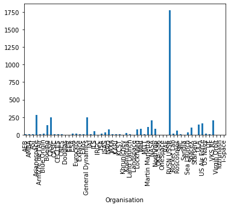

```python
df_data.groupby(['Organisation']).size().plot(kind = "bar")
```

# Number of Active versus Retired Rockets

How many rockets are active compared to those that are decomissioned?

[figure not shown]

```python
result =df_data.groupby(['Organisation']).size()

# plot the result
sns.barplot(x = result.index, y = result.values)
```

```python
df_data[df_data['Rocket_Status']=="StatusActive"].index
```

```
Int64Index([   0,    1,    2,    3,    4,    5,    6,    7,    8,    9,
            ...
            1684, 1794, 1932, 1980, 1986, 2041, 2101, 2177, 2249, 2309],
           dtype='int64', length=790)
```

```python
df_data[df_data['Rocket_Status']=="StatusRetired"].index
```

```
Int64Index([  29,   64,   98,  100,  105,  107,  122,  145,  154,  155,
            ...
            4314, 4315, 4316, 4317, 4318, 4319, 4320, 4321, 4322, 4323],
           dtype='int64', length=3534)
```

# Distribution of Mission Status

How many missions were successful? How many missions failed?

```python
df_data[df_data['Mission_Status']=="Success"].index
```

```
Int64Index([   0,    1,    2,    3,    4,    5,    6,    7,    8,    9,
            ...
            4289, 4291, 4293, 4309, 4313, 4316, 4317, 4320, 4322, 4323],
           dtype='int64', length=3879)
```

```python
df_data[df_data['Mission_Status']=="Failure"].index
```

```
Int64Index([  11,   15,   27,   36,   43,   52,   91,  124,  137,  152,
            ...
            4307, 4308, 4310, 4311, 4312, 4314, 4315, 4318, 4319, 4321],
           dtype='int64', length=339)
```

# How Expensive are the Launches?

Create a histogram and visualise the distribution. The price column is given in USD millions (careful of missing values).

[figure not shown]

```python
result =df_data.groupby(['Price']).size()

# plot the result
sns.barplot(x = result.index, y = result.values)
```

```python
df_data['Country']=df_data['Location'].str.split(",").str[-1].str.strip()
```

```python
df_data['Country']
```

```
0              USA
1            China
2              USA
3       Kazakhstan
4              USA
           ...
4319           USA
4320           USA
4321           USA
4322    Kazakhstan
4323    Kazakhstan
Name: Country, Length: 4324, dtype: object
```

```python
# count=-1
# n=[]
# for i in new[3]:
#     count=count+1
#     if str(i)=="None":
#         n.append(str(new[2][count]).strip())
#     else:
#         n.append("USA")
```

```python
df_data['Country'][df_data['Country']=='Yellow Sea']="China"
```

```python
df_data.loc[df_data['Country']==' Russia', "Country"] = "Russian Federation"
```

```python
df_data.loc[df_data['Country']==' New Mexico', "Country"] = "USA"
```

```python
df_data.loc[df_data['Country']=='Shahrud Missile Test Site', "Country"] = "Iran"
```

```python
df_data.loc[df_data['Country']=='Pacific Missile Range Facility', "Country"] = "USA"
```

```python
df_data.loc[df_data['Country']=='Barents Sea', "Country"] = "Russian Federation"
```

```python
df_data.loc[df_data['Country']=='Gran Canaria', "Country"] = "USA"
```

# Use a Choropleth Map to Show the Number of Launches by Country

- Create a choropleth map using [the plotly documentation](https://plotly.com/python/choropleth-maps/)
- Experiment with [plotly's available colours](https://plotly.com/python/builtin-colorscales/). I quite like the sequential colour `matter` on this map.
- You'll need to extract a `country` feature as well as change the country names that no longer exist.

Wrangle the Country Names

You'll need to use a 3 letter country code for each country. You might have to change some country names.

- Russia is the Russian Federation
- New Mexico should be USA
- Yellow Sea refers to China
- Shahrud Missile Test Site should be Iran
- Pacific Missile Range Facility should be USA
- Barents Sea should be Russian Federation
- Gran Canaria should be USA

You can use the iso3166 package to convert the country names to Alpha3 format.

```python
pip install pycountry
```

[output not shown]

```python
import pycountry
countries = {}
for country in pycountry.countries:
    countries[country.name] = country.alpha_3
countries["USA"]= "USA"

codes = [countries.get(country) for country in df_data["Country"]]
print(codes)  # prints ['AS', 'CA', 'FR']
```

[output not shown]

```python
df_data["Codes"]=pd.Series(codes)
```

```python
df_data["Codes"]
```

```
0       USA
1       CHN
2       USA
3       KAZ
4       USA
       ...
4319    USA
4320    USA
4321    USA
4322    KAZ
4323    KAZ
Name: Codes, Length: 4324, dtype: object
```

```python
df_data.dropna()
```

|  | Organisation | Location | Date | Detail | Rocket_Status | Price | Mission_Status | Country | Codes |
| --- | --- | --- | --- | --- | --- | --- | --- | --- | --- |
| 0 | SpaceX | LC-39A, Kennedy Space Center, Florida, USA | Fri Aug 07, 2020 05:12 UTC | Falcon 9 Block 5 \| Starlink V1 L9 & BlackSky | StatusActive | 50.0 | Success | USA | USA |
| 1 | CASC | Site 9401 (SLS-2), Jiuquan Satellite Launch Ce... | Thu Aug 06, 2020 04:01 UTC | Long March 2D \| Gaofen-9 04 & Q-SAT | StatusActive | 29.75 | Success | China | CHN |
| 3 | Roscosmos | Site 200/39, Baikonur Cosmodrome, Kazakhstan | Thu Jul 30, 2020 21:25 UTC | Proton-M/Briz-M \| Ekspress-80 & Ekspress-103 | StatusActive | 65.0 | Success | Kazakhstan | KAZ |
| 4 | ULA | SLC-41, Cape Canaveral AFS, Florida, USA | Thu Jul 30, 2020 11:50 UTC | Atlas V 541 \| Perseverance | StatusActive | 145.0 | Success | USA | USA |
| 5 | CASC | LC-9, Taiyuan Satellite Launch Center, China | Sat Jul 25, 2020 03:13 UTC | Long March 4B \| Ziyuan-3 03, Apocalypse-10 & N... | StatusActive | 64.68 | Success | China | CHN |
| ... | ... | ... | ... | ... | ... | ... | ... | ... | ... |
| 3855 | US Air Force | SLC-4W, Vandenberg AFB, California, USA | Fri Jul 29, 1966 18:43 UTC | Titan IIIB \| KH-8 | StatusRetired | 59.0 | Success | USA | USA |
| 3971 | US Air Force | SLC-20, Cape Canaveral AFS, Florida, USA | Thu May 06, 1965 15:00 UTC | Titan IIIA \| LES 2 & LCS 1 | StatusRetired | 63.23 | Success | USA | USA |
| 3993 | US Air Force | SLC-20, Cape Canaveral AFS, Florida, USA | Thu Feb 11, 1965 15:19 UTC | Titan IIIA \| LES 1 | StatusRetired | 63.23 | Success | USA | USA |
| 4000 | US Air Force | SLC-20, Cape Canaveral AFS, Florida, USA | Thu Dec 10, 1964 16:52 UTC | Titan IIIA \| Transtage 2 | StatusRetired | 63.23 | Success | USA | USA |
| 4020 | US Air Force | SLC-20, Cape Canaveral AFS, Florida, USA | Tue Sep 01, 1964 15:00 UTC | Titan IIIA \| Transtage 1 | StatusRetired | 63.23 | Failure | USA | USA |

910 rows × 9 columns

# Use a Choropleth Map to Show the Number of Failures by Country

```python
df_data_failure=df_data[df_data["Mission_Status"]=="Failure"]
```

```python
df_data_failure=df_data_failure.Codes.value_counts().reset_index().rename(columns={'index':'Country','Codes':'Failure_Count'})
```

```python
import plotly.express as px

fig = px.choropleth(df_data_failure, locations="Country",
                    color="Failure_Count", # lifeExp is a column of gapminder
                    hover_name="Country", # column to add to hover information
                    color_continuous_scale=px.colors.sequential.Plasma)
fig.show()
```

[interactive chart not shown]

```python
new=df_data_failure["Mission_Status"].count()
```

```python
df_data_failure["Country"]
```

[output not shown]

# Create a Plotly Sunburst Chart of the countries, organisations, and mission status.

```python
import plotly.express as px
fig = px.sunburst(
    df_data,
    names='Country',
    parents='Organisation',
    values='Mission_Status',
)
fig.show()
```

[interactive chart not shown]

# Analyse the Total Amount of Money Spent by Organisation on Space Missions

```python
df_data["Price"]=pd.to_numeric(df_data["Price"])
np.sum(df_data["Price"])
```

[output not shown]

```python
df_data=df_data.dropna()
```

```python
df_data["Price"]=df_data["Price"].str.replace(',', '').astype(float)
```

```python
df_data["Price"]
```

```
0       50.00
1       29.75
3       65.00
4      145.00
5       64.68
        ...
3855    59.00
3971    63.23
3993    63.23
4000    63.23
4020    63.23
Name: Price, Length: 903, dtype: float64
```

```python
print("Total Amount Spent in millions:",df_data["Price"].sum())
```

```
Total Amount Spent in millions: 145865.30000000002
```

# Analyse the Amount of Money Spent by Organisation per Launch

```python
org=df_data.groupby(['Organisation'])
```

```python
org["Price"].sum()
```

```
Organisation
Arianespace       16,345.00
Boeing             1,241.00
CASC               6,234.18
EER                   20.00
ESA                   37.00
ExPace                28.30
ILS                1,320.00
ISRO               2,177.00
JAXA                 168.00
Kosmotras            348.00
Lockheed             280.00
MHI                3,532.50
Martin Marietta      721.40
NASA              76,280.00
Northrop           3,850.00
RVSN USSR         10,000.00
Rocket Lab            97.50
Roscosmos          1,055.50
SpaceX             5,444.00
ULA               14,798.00
US Air Force       1,550.92
VKS RF               325.00
Virgin Orbit          12.00
Name: Price, dtype: float64
```

# Chart the Number of Launches per Year

```python
year_new=df_data["Date"].str.split(pat=' ', n=4, expand = True)
```

```python
year_new
```

[output not shown]

4324 rows × 5 columns

```python
year_new[3]
```

```
0       2020
1       2020
2       2020
3       2020
4       2020
        ...
4319    1958
4320    1958
4321    1957
4322    1957
4323    1957
Name: 3, Length: 4324, dtype: object
```

```python
df_data["Year"]=pd.Series(year_new[3])
```

```python
 pd.options.mode.chained_assignment = None
```

```python
df_data["Year"]
```

[output not shown]

```python
year=df_data.groupby(['Year'])
```

```python
year["Year"].count()
```

[output not shown]

# Chart the Number of Launches Month-on-Month until the Present

Which month has seen the highest number of launches in all time? Superimpose a rolling average on the month on month time series chart.

```python
df_data["Month"]=year_new[1]
```

```python
Month=df_data.groupby(['Month'])
```

```python
month_count=Month["Month"].count()
```

```python
roll_avg =Month["Month"].count().rolling(7).mean()
```

[output not shown]

[figure not shown]

```python
# set figure size
plt.figure( figsize = ( 12, 5))

# plot a simple time series plot
# using seaborn.lineplot()
lab = [ 'Jan', 'Feb', 'Mar', 'Apr', 'May', 'June',
       'July', 'Aug', 'Sept', 'Oct', 'Nov', 'Dec']
sns.lineplot(x = lab,
             y =month_count  ,
             label = 'Launches')
sns.lineplot( x = lab,
             y = roll_avg,
             label = 'Rollingavg')
plt.xlabel( 'Launches')

# setting customized ticklabels for x axis

plt.xticks(lab)
```